# NBA Fan Support

##Summary of Project

Sports are a staple of American culture, and fans are always interested in statistics related to their favorite team, including popularity trends. Popularity trends can also be useful from a business standpoint, as it can provide advertisers with valuable data about which teams are notably popular at a given point in time. The support for a particular sports team ebbs and flows over time as well, varying with team success and time of year, such as an increase in popularity during playoffs and a sharp decrease in popularity immediately after.

A recent example of this can be seen with the Golden State Warriors, who have seen a huge surge in popularity during the last 5 years, after winning several NBA Championships. Popularity for a certain team can be measured via search data available on Google Trends, which provides data on the relative popularity of terms that are searched for on Google.

The main goal of this proect is to analyze the popularity of NBA teams over time throughout the United States. We are focused on comparing the search popularity for all 30 NBA teams throughout time, and creating mathematical model to predict the yearly pattern of team support, correcting for team performance, playoffs, and other factors. This model is then used to discover the differences in support patterns between teams and potentially identify bandwagon fans, as well as if whether some teams are more prone to attract bandwagon fans than others.

The data for popularity scores was all collected from Google Trends, and contains the relative popularity scores for all 30 NBA teams for each month from January 2004 to present. In order to correct for the fact that all of the popularity scores for each team are relative to the peak popularity for that specific team, all scores were compared to the absolute max popularity score, which is the Golden State Warriors in June 2016.

##Exploratory Data Analysis

| Team | Popularity |
| --- | --- |
| LosAngelesLakers | 8.5934066 |
| GoldenStateWarriors | 7.6978022 |
| ClevelandCavaliers | 6.7307692 |
| BostonCeltics | 4.8516484 |
| MiamiHeat | 4.5549451 |
| ChicagoBulls | 4.0989011 |
| NewYorkKnicks | 3.7362637 |
| SanAntonioSpurs | 3.6318681 |
| HoustonRockets | 2.9065934 |
| OklahomaCityThunder | 2.6373626 |

[output cut: 20 more lines]

*To get a sense of which teams are overall more popular than others since 2004, I computed the average popularity scores across all time points for each team. Here we see that the teams with the highest average popularity scores are the Los Angeles Lakers, Golden State Warriors, and Cleveland Cavaliers. These results make sense as these teams have been wildly succesful throughout the last 15 years.*

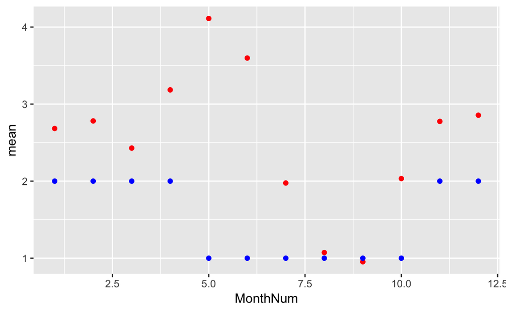

```r
#Scatterplot with mean and median Popularity score by month
#Red = Mean , Blue = Median
NBATeams %>%
  group_by(MonthNum) %>%
  summarize_at(vars(Popularity), funs(mean, median)) %>%
  ggplot() + geom_point(aes(x = MonthNum, y = mean), col = "red") +
  geom_point(aes(x = MonthNum, y = median), col = "blue")
```

I also expected there to be a difference in popularity scores throughout the years, as I expect teams to overall be more popular during the NBA Playoffs (which encompasses the months of April-June) and less popular during the NBA offseason (which encompasses the months of July-October).

To see if this is indeed the case, I plotted both the mean and median popularity score for each month. In the plot above, the red dots represent the mean popularity score for each month, whereas the blue dots represent the median popularity score for each month. We can indeed see that during the months of the NBA playoffs, the mean popularity scores are higher, peaking in May. The mean and median popularity scores are also much further apart in these months than in other months, as the mean is likely highly skewed by teams which make deep playoff runs, and as a result see a large increase in popularity.

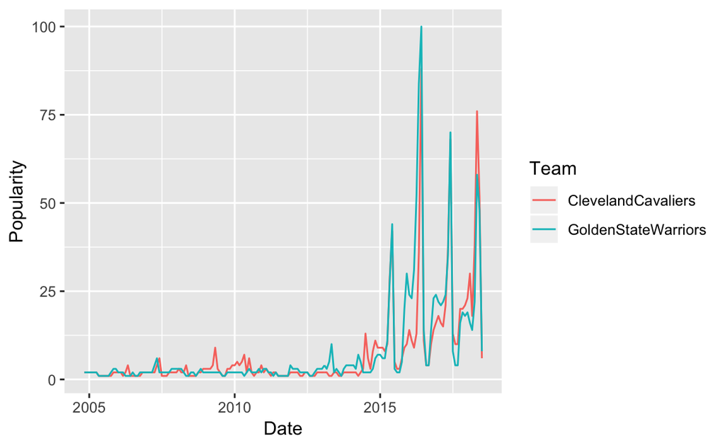

Next, I decided to take a closer look at the popularity of two specific teams in the NBA. I decided to focus on the Cleveland Cavaliers and Golden State Warriors, because the earlier exploratory analysis indicated that these teams have two of the highest mean popularity scores. These teams have also experienced a lot of recent success, having played each other in the NBA Finals for the past 4 years.

Plotted above is the popularity scores for both the Cleveland Cavaliers and the Golden State Warriors from the beginning of the 2004 NBA Season to the end of the 2018 NBA season. We can see that the the popularity scores for both teams are both fairly low until around 2015, where the Warriors experience a large spike in Popularity score that is nearly 50. We then see that these teams continue to see large spikes in popularity for the following years, with a peak in 2016, as the Warriors achieved a popularity score of 100 in June 2016. This is interesting to note, as it appears that these two teams have become much more popular in recent years.

```r
aggregate(W.L. ~ Team, NBATeams, mean) %>% arrange(desc(W.L.))
```

| Team | W.L. |
| --- | --- |
| SanAntonioSpurs | 0.7155333 |
| OklahomaCityThunder | 0.6074000 |
| DallasMavericks | 0.5986000 |
| HoustonRockets | 0.5923333 |
| MiamiHeat | 0.5734000 |
| BostonCeltics | 0.5601333 |
| GoldenStateWarriors | 0.5555333 |
| DenverNuggets | 0.5494667 |
| ClevelandCavaliers | 0.5434000 |
| ChicagoBulls | 0.5329333 |

[output cut: 20 more lines]

```r
aggregate(Popularity ~ Team, NBATeams, mean) %>% arrange(desc(Popularity))
```

| Team | Popularity |
| --- | --- |
| LosAngelesLakers | 8.5934066 |
| GoldenStateWarriors | 7.6978022 |
| ClevelandCavaliers | 6.7307692 |
| BostonCeltics | 4.8516484 |
| MiamiHeat | 4.5549451 |
| ChicagoBulls | 4.0989011 |
| NewYorkKnicks | 3.7362637 |
| SanAntonioSpurs | 3.6318681 |
| HoustonRockets | 2.9065934 |
| OklahomaCityThunder | 2.6373626 |

[output cut: 20 more lines]

Next, I decided to investigate some descriptive statistics to see if there appears to be somewhat of a relationship between Win/Loss percentage and Popularity score, because I hypothesize that teams that are performing better are more likely to have higher popularity scores.

Upon viewing the mean win percentages for each team, we see that the teams with the highest win percentages since 2004 are the San Antonio Spurs, the Oklahoma City Thunder, and the Dallas Mavericks. Meanwhile the teams with the lowest win percentages are the Minnesota Timberwolves, the Philadelphia 76ers, and the Sacramento Kings.

When comparing the win percentages and the popularity scores for each team, we can see that there is somewhat of an association between win percentage and search popularity. The teams with the top 3 win percentages since 2004 which are the San Antonio Spurs, the Oklahoma City Thunder, and the Dallas Mavericks, are also within the top 11 for mean popularity score. This may seem to indicate that teams that have higher win percentages are likely to have higher popularity scores.

##Model Fitting

```r
seasondata_model <- lm(Popularity ~ Team + factor(MonthNum):(W.L. + Playoffs)
                       , data = NBATeams)
summary(seasondata_model)
```

```
Call:
lm(formula = Popularity ~ Team + factor(MonthNum):(W.L. + Playoffs),
    data = NBATeams)

Residuals:
    Min      1Q  Median      3Q     Max
-24.958  -1.156  -0.105   0.803  66.849

Coefficients:
                                              Estimate Std. Error t value
(Intercept)                                  -2.208611   0.363285  -6.080
TeamBostonCeltics                             2.233022   0.400551   5.575
TeamBrooklynNets                              0.764562   0.525719   1.454
TeamCharlotteHornets                         -0.301294   0.615811  -0.489
TeamChicagoBulls                              2.347392   0.398705   5.888
TeamClevelandCavaliers                        3.563354   0.406366   8.769
TeamDallasMavericks                          -0.483350   0.404679  -1.194
TeamDenverNuggets                            -0.919100   0.404445  -2.272
TeamDetroitPistons                           -0.807154   0.403601  -2.000
TeamGoldenStateWarriors                       4.357216   0.408695  10.661
TeamHoustonRockets                            0.408893   0.405858   1.007
TeamIndianaPacers                            -0.664644   0.400188  -1.661
TeamLosAngelesClippers                        0.004453   0.399992   0.011
TeamLosAngelesLakers                          5.594662   0.402756  13.891
TeamMemphisGrizzlies                         -0.924392   0.398450  -2.320
TeamMiamiHeat                                 1.165728   0.406376   2.869
TeamMilwaukeeBucks                            0.212315   0.400417   0.530
TeamMinnesotaTimberwolves                    -0.403737   0.404382  -0.998
TeamNewOrleansPelicans                       -0.489401   0.566817  -0.863
TeamNewYorkKnicks                             2.356408   0.400423   5.885
TeamOklahomaCityThunder                       0.808076   0.453136   1.783
TeamOrlandoMagic                             -0.872867   0.399971  -2.182
TeamPhiladelphia76ers                         0.714108   0.399404   1.788
TeamPhoenixSuns                              -0.677197   0.405519  -1.670
TeamPortlandTrailBlazers                     -0.391837   0.400941  -0.977
TeamSacramentoKings                          -0.109255   0.401193  -0.272
TeamSanAntonioSpurs                          -0.599354   0.415094  -1.444
TeamTorontoRaptors                           -1.212735   0.401353  -3.022
TeamUtahJazz                                 -0.941889   0.402083  -2.343
TeamWashingtonWizards                         0.243707   0.397761   0.613
```

[output cut: 167 more lines]

```
factor(MonthNum)5:PlayoffsWon Finals         5.25e-14 ***
factor(MonthNum)6:PlayoffsWon Finals          < 2e-16 ***
factor(MonthNum)7:PlayoffsWon Finals         0.086833 .
factor(MonthNum)8:PlayoffsWon Finals         0.041855 *
factor(MonthNum)9:PlayoffsWon Finals         0.052305 .
factor(MonthNum)10:PlayoffsWon Finals        0.156326
factor(MonthNum)11:PlayoffsWon Finals        0.640211
factor(MonthNum)12:PlayoffsWon Finals        0.244978
---
Signif. codes:  0 ‘***’ 0.001 ‘**’ 0.01 ‘*’ 0.05 ‘.’ 0.1 ‘ ’ 1

Residual standard error: 3.765 on 4878 degrees of freedom
  (480 observations deleted due to missingness)
Multiple R-squared:  0.4557,    Adjusted R-squared:  0.4445
F-statistic: 40.44 on 101 and 4878 DF,  p-value: < 2.2e-16
```

```r
NBATeams <- NBATeams %>% add_predictions(seasondata_model)
```

After viewing these exploratory results, I decided to fit a very robust linear model to predict Popularity scores. This model uses the predictors of Team, interaction terms between each month of the year and Win/Loss record, as well as the interaction terms between each month of the year and each possible Playoff result (Did Not Make Playoffs, Lost in 1st Round, Lost Conference Semifinals, Lost Conference Finals, Lost NBA Finals, and Won NBA Finals).

However, it is also interesting to note that the interaction terms for the other months of the year(aside from August) and Winning/Losing the NBA Finals are not statistically signficant. This appears to indicate that that are performing well throughout the year and do go on to perform well in the NBA Playoffs typically do not see a large increase in popularity until they are actually playing in the NBA Finals.

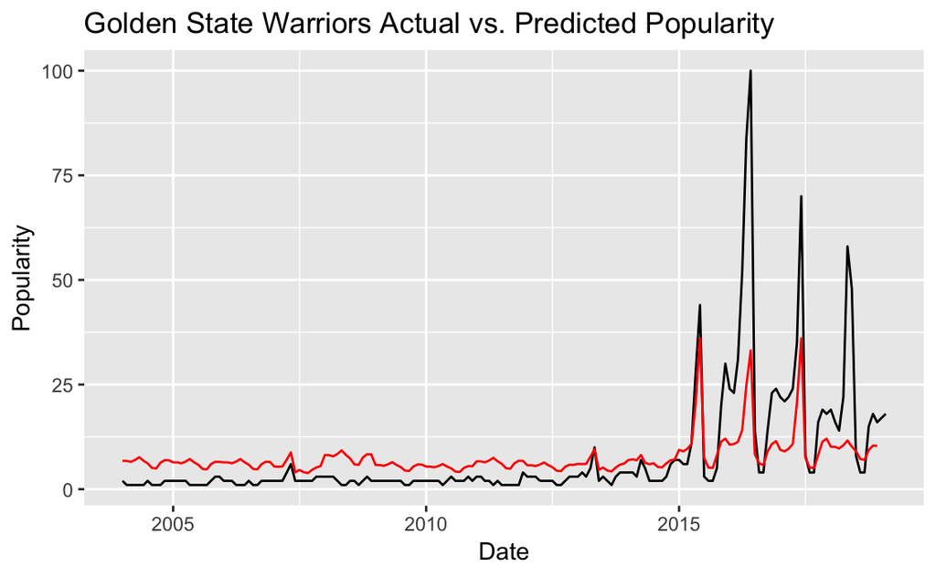

```r
NBATeams %>%
  filter(Team == "GoldenStateWarriors") %>%
  ggplot() + geom_line(aes(x = Date, y = Popularity)) + geom_line(aes(x = Date, y = pred), col = "red") +
  ggtitle("Golden State Warriors Actual vs. Predicted Popularity")
```

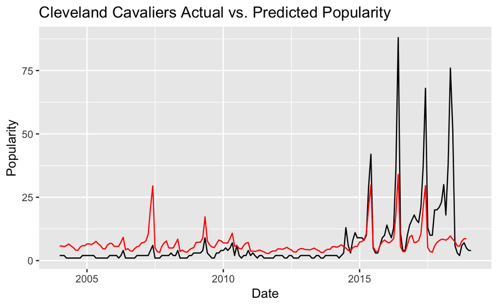

```r
NBATeams %>%
  filter(Team == "ClevelandCavaliers") %>%
  ggplot() + geom_line(aes(x = Date, y = Popularity)) + geom_line(aes(x = Date, y = pred), col = "red") +
  ggtitle("Cleveland Cavaliers Actual vs. Predicted Popularity")
```

Now that we have the predictions for popularity score from the model above, we can see how the predictions from this model compare to the actual popularity scores. Since the exploratory data analysis indicated that the Golden State Warriors and Cleveland Cavaliers may be teams of interest, I will examine plots for each of these teams.

The first plot is the Actual vs. Predicted Popularity scores for the Golden State Warriors, across all times. The red line indicates the predicted popularity scores, whereas the black line indicates the observed popularity scores. We can see that from roughly 2004-2015, the model tends to consistently overpredict the popularity scores for the Warriors, meaning that the Warriors a bit less popular than we would expect throughout these years. Following 2015, however, the observed popularity scores are much higher than the model predicts, especially during the months of May and June when the Warriors played in the NBA Finals.

In the plot examining the Actual vs. Predicted Popularity scores for the Cleveland Cavaliers, we see a very similar trend. After 2015, the observed popularity scores for the Cleveland Cavaliers tend to be much larger than the predicted popularity scores, also peaking during the months of the NBA Finals.

These plots may give us some initial evidence of the “Bandwagon effect”. This is a common phrase often used in sports to describe teams who seem to have a large amount of supporters when they are performing well, but these supporters seem to dissappear when the team is no longer performing well. Both of these plots seem to suggest that the Warriors and Cavaliers tend to be more popular than predicted when they are playing well, and less popular than predicted when they are not performing well, which is typically described as a “bandwagon effect”.

#Detecting differences across playoff performance

```r
PlayoffsAnova <- lm(Popularity~Playoffs, data=NBATeams)
anova(PlayoffsAnova)
```

```
Analysis of Variance Table

Response: Popularity
            Df Sum Sq Mean Sq F value    Pr(>F)
Playoffs     5  14980 2996.03  140.21 < 2.2e-16 ***
Residuals 5454 116544   21.37
---
Signif. codes:  0 ‘***’ 0.001 ‘**’ 0.01 ‘*’ 0.05 ‘.’ 0.1 ‘ ’ 1
```

```r
aov.fit1 <- aov(Popularity ~ Playoffs, data=NBATeams)
posthoc <- TukeyHSD(x=aov.fit1, conf.level=0.95)
posthoc
```

```
  Tukey multiple comparisons of means
    95% family-wise confidence level

Fit: aov(formula = Popularity ~ Playoffs, data = NBATeams)

$Playoffs
                                                diff        lwr       upr
Lost 1st Round-Did Not Make Playoffs     0.006224336 -0.4368543 0.4493029
Lost Conf. Finals-Did Not Make Playoffs  1.394308343  0.6349497 2.1536670
Lost Conf. Semis-Did Not Make Playoffs   0.888531032  0.3024026 1.4746595
Lost Finals-Did Not Make Playoffs        6.885379772  5.8396968 7.9310628
Won Finals-Did Not Make Playoffs         6.861570248  5.8158873 7.9072532
Lost Conf. Finals-Lost 1st Round         1.388084007  0.5797847 2.1963833
Lost Conf. Semis-Lost 1st Round          0.882306696  0.2340253 1.5305881
Lost Finals-Lost 1st Round               6.879155436  5.7974091 7.9609018
Won Finals-Lost 1st Round                6.855345912  5.7735996 7.9370922
Lost Conf. Semis-Lost Conf. Finals      -0.505777311 -1.4005263 0.3889716
Lost Finals-Lost Conf. Finals            5.491071429  4.2458879 6.7362550
Won Finals-Lost Conf. Finals             5.467261905  4.2220784 6.7124454
Lost Finals-Lost Conf. Semis             5.996848739  4.8490669 7.1446305
Won Finals-Lost Conf. Semis              5.973039216  4.8252574 7.1208210
Won Finals-Lost Finals                  -0.023809524 -1.4616236 1.4140046
                                            p adj
Lost 1st Round-Did Not Make Playoffs    1.0000000
Lost Conf. Finals-Did Not Make Playoffs 0.0000026
Lost Conf. Semis-Did Not Make Playoffs  0.0002282
Lost Finals-Did Not Make Playoffs       0.0000000
Won Finals-Did Not Make Playoffs        0.0000000
Lost Conf. Finals-Lost 1st Round        0.0000149
Lost Conf. Semis-Lost 1st Round         0.0014788
Lost Finals-Lost 1st Round              0.0000000
Won Finals-Lost 1st Round               0.0000000
Lost Conf. Semis-Lost Conf. Finals      0.5909569
Lost Finals-Lost Conf. Finals           0.0000000
Won Finals-Lost Conf. Finals            0.0000000
Lost Finals-Lost Conf. Semis            0.0000000
Won Finals-Lost Conf. Semis             0.0000000
Won Finals-Lost Finals                  1.0000000
```

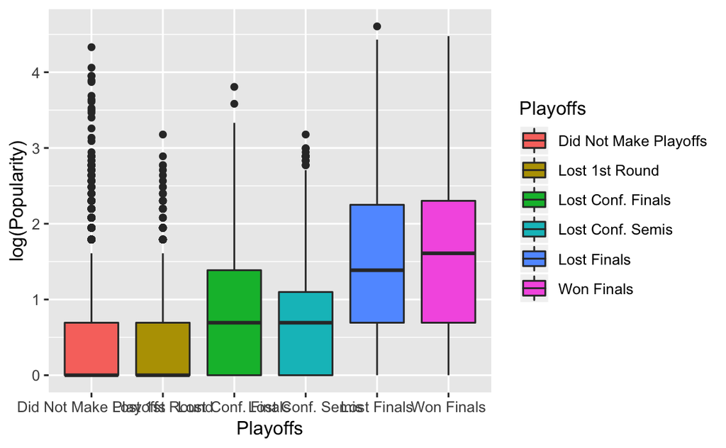

```r
ggplot(NBATeams, aes(y = log(Popularity), x = Playoffs, fill = Playoffs)) + geom_boxplot()
```